# Population genetics summer course 2025, Denmark

# Local Ancestry Inference Exercise

## Setup Environment

```
COURSE_PATH=/course/popgen25
DATA_PATH=${COURSE_PATH}/LocalAncestry
SOFTWARE_PATH=${COURSE_PATH}/software

# go to working folder
mkdir -p ~/popgen25_localancestry
cd ~/popgen25_localancestry


ln -sfn ~/popgen25_localancestry ~/current_folder
ln -sfn ${DATA_PATH} ~/data_folder
```

```
FLARE=${SOFTWARE_PATH}/flare.jar
MOSAIC=${SOFTWARE_PATH}/mosaic.R

which bcftools

ls ${FLARE}
ls ${MOSAIC}
```

```
/bin/bcftools
/course/popgen25/software/flare.jar
/course/popgen25/software/mosaic.R
```

## Exercise

#### For this practical we will infer local ancestry in simulated data using two methods: FLARE and MOSAIC. We will compare the outputs from the two methods for different demographic models and show how their performance may differ.

We will use simulated data from two toy models, with gene flow happening either at 20 or 200 generations ago.

If you're interested in how the data was simulated, please refer to the slendr R package: https://slendr.net/index.html

Let's take a look at the demographic model based on which we simulated genetic data.

One ancestral population "pop" splits into two populations (pop_b and pop_c) 1500 generations ago. At 400 generations ago, pop_mix splits from pop_b, and then subsequent gene flow occurs from pop_c into pop_mix either 20 or 200 generations ago.

##### Gene flow from pop_c into pop_mix 20 generations ago:

```
import os
from IPython.display import Image
Image(filename=os.path.expanduser('~/data_folder/model_gen_adm_20.png'))
```

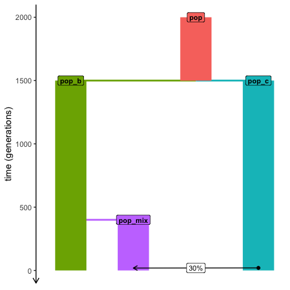

##### Gene flow from pop_c into pop_mix 200 generations ago:

```
import os
from IPython.display import Image
Image(filename=os.path.expanduser('~/data_folder/model_gen_adm_200.png'))
```

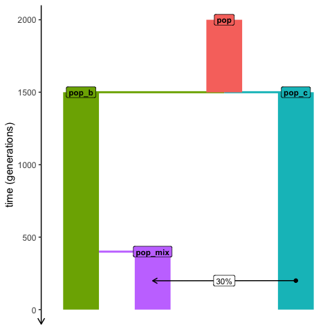

##### Let's have a look at the files available for each scenario

```
ls ~/data_folder/model*
```

```
/home/jupyter-shixu/data_folder/model_gen_adm_20.png
/home/jupyter-shixu/data_folder/model_gen_adm_20.vcf.gz
/home/jupyter-shixu/data_folder/model_gen_adm_200.png
/home/jupyter-shixu/data_folder/model_gen_adm_200.vcf.gz
/home/jupyter-shixu/data_folder/model_gen_adm_200_filt.vcf.gz
/home/jupyter-shixu/data_folder/model_gen_adm_200_fst.tsv
/home/jupyter-shixu/data_folder/model_gen_adm_200_meta.tsv
/home/jupyter-shixu/data_folder/model_gen_adm_200_tracts.tsv
/home/jupyter-shixu/data_folder/model_gen_adm_20_filt.vcf.gz
/home/jupyter-shixu/data_folder/model_gen_adm_20_fst.tsv
/home/jupyter-shixu/data_folder/model_gen_adm_20_meta.tsv
/home/jupyter-shixu/data_folder/model_gen_adm_20_tracts.tsv
```

##### Focusing on the scenario where gene flow happens 20 generation ago, let's take a look at the metadata file

```
head -n 50 ~/data_folder/model_gen_adm_20_meta.tsv
```

```
name	time	pop
pop_b_1	1200	pop_b
pop_b_2	1200	pop_b
pop_b_3	1200	pop_b
pop_b_4	1200	pop_b
pop_b_5	1200	pop_b
pop_b_6	1200	pop_b
pop_b_7	1200	pop_b
pop_b_8	1200	pop_b
pop_b_9	1200	pop_b
pop_b_10	1200	pop_b
pop_b_11	1200	pop_b
pop_b_12	1200	pop_b
pop_b_13	1200	pop_b
pop_b_14	1200	pop_b
pop_b_15	1200	pop_b
pop_b_16	1200	pop_b
pop_b_17	1200	pop_b
pop_b_18	1200	pop_b
pop_b_19	1200	pop_b
pop_b_20	1200	pop_b
pop_b_21	1200	pop_b
pop_b_22	1200	pop_b
pop_b_23	1200	pop_b
pop_b_24	1200	pop_b
pop_b_25	1200	pop_b
pop_b_26	1200	pop_b
pop_b_27	1200	pop_b
pop_b_28	1200	pop_b
pop_b_29	1200	pop_b
pop_b_30	1200	pop_b
pop_b_31	1200	pop_b
pop_b_32	1200	pop_b
pop_b_33	1200	pop_b
pop_b_34	1200	pop_b
pop_b_35	1200	pop_b
pop_b_36	1200	pop_b
pop_b_37	1200	pop_b
pop_b_38	1200	pop_b
pop_b_39	1200	pop_b
pop_b_40	1200	pop_b
pop_b_41	1200	pop_b
pop_b_42	1200	pop_b
pop_b_43	1200	pop_b
pop_b_44	1200	pop_b
pop_b_45	1200	pop_b
pop_b_46	1200	pop_b
pop_b_47	1200	pop_b
pop_b_48	1200	pop_b
pop_b_49	1200	pop_b
```

#### Q: How many samples are taken at each time point and population?

```
suppressMessages(library(dplyr))

meta <- read.delim('~/data_folder/model_gen_adm_20_meta.tsv')
meta %>%
    group_by(time, pop) %>%
    tally()
```

A grouped_df: 5 × 3

| time <int> | pop <chr> | n <int> |
| --- | --- | --- |
| 0 | pop_b | 50 |
| 0 | pop_c | 50 |
| 0 | pop_mix | 10 |
| 1200 | pop_b | 50 |
| 1200 | pop_c | 50 |

##### Let's do the same for the scenario with gene flow happening 200 generations ago:

```
suppressMessages(library(dplyr))

meta <- read.delim('~/data_folder/model_gen_adm_200_meta.tsv')
meta %>%
    group_by(time, pop) %>%
    tally()
```

A grouped_df: 5 × 3

| time <int> | pop <chr> | n <int> |
| --- | --- | --- |
| 0 | pop_b | 50 |
| 0 | pop_c | 50 |
| 0 | pop_mix | 10 |
| 1200 | pop_b | 50 |
| 1200 | pop_c | 50 |

We can see that in both demographic scenarios, we have 10 individuals from pop_mix from one time point (0=present), and 50 from pop_b and 50 from pop_c from two different time points (0 and 1200 generations ago).

Let's focus a bit on the sources sampled at two different time points, 0 and 1200 generations before present. Specifically, let's see how differentiated pop_b and pop_c are in each case.

##### From the simulated data, we have estimated FST values between pop_b and pop_c at both time points. (Remember FST?!) Let's load the estimates and take a look:

```
cat ~/data_folder/model_gen_adm_20_fst.tsv
```

```
x	y	Fst	time
popb	popc	0.0361756359927008	0
popb	popc	0.00718249033015672	1200
```

#### Q: Do the fst values differ? Why?

Let's keep this difference in the back of our minds for a bit, it might come in handy again later in the exercise.

##### Time to dive into the true ancestry tracks from the two scenarios. Let's load the tracts for each:

```
head -n 50 ~/data_folder/model_gen_adm_20_tracts.tsv
```

```
name	node_id	pop	source_pop	length	source_pop_id	left	right	adm_time
pop_mix_1	400	pop_mix	pop_b	17138143	2	0	17138143	20
pop_mix_1	401	pop_mix	pop_b	66535142	2	0	66535142	20
pop_mix_10	418	pop_mix	pop_b	0	2	0	0	20
pop_mix_10	419	pop_mix	pop_b	0	2	0	0	20
pop_mix_2	402	pop_mix	pop_b	0	2	0	0	20
pop_mix_2	403	pop_mix	pop_b	5293561	2	0	5293561	20
pop_mix_3	404	pop_mix	pop_b	304274	2	0	304274	20
pop_mix_3	405	pop_mix	pop_b	572564	2	0	572564	20
pop_mix_4	406	pop_mix	pop_b	0	2	0	0	20
pop_mix_4	407	pop_mix	pop_b	7730939	2	0	7730939	20
pop_mix_5	408	pop_mix	pop_b	56114516	2	0	56114516	20
pop_mix_5	409	pop_mix	pop_b	3559073	2	0	3559073	20
pop_mix_6	410	pop_mix	pop_b	11865692	2	0	11865692	20
pop_mix_6	411	pop_mix	pop_b	9830156	2	0	9830156	20
pop_mix_7	412	pop_mix	pop_b	44081083	2	0	44081083	20
pop_mix_7	413	pop_mix	pop_b	10503194	2	0	10503194	20
pop_mix_8	414	pop_mix	pop_b	6511979	2	0	6511979	20
pop_mix_8	415	pop_mix	pop_b	691315	2	0	691315	20
pop_mix_9	416	pop_mix	pop_b	64699908	2	0	64699908	20
pop_mix_9	417	pop_mix	pop_b	77086	2	0	77086	20
pop_mix_1	400	pop_mix	pop_b	10523990	2	27266540	37790530	20
pop_mix_1	400	pop_mix	pop_b	6188886	2	38592738	44781624	20
pop_mix_1	400	pop_mix	pop_b	3171147	2	56366814	59537961	20
pop_mix_1	400	pop_mix	pop_b	3579180	2	59814192	63393372	20
pop_mix_1	400	pop_mix	pop_b	25817804	2	70729157	96546961	20
pop_mix_1	400	pop_mix	pop_b	-1	2	100000001	100000000	20
pop_mix_1	401	pop_mix	pop_b	9001998	2	74489619	83491617	20
pop_mix_1	401	pop_mix	pop_b	15615992	2	83881302	99497294	20
pop_mix_1	401	pop_mix	pop_b	-1	2	100000001	100000000	20
pop_mix_2	402	pop_mix	pop_b	58818726	2	7131159	65949885	20
pop_mix_2	402	pop_mix	pop_b	16063637	2	83936363	100000000	20
pop_mix_2	403	pop_mix	pop_b	4860540	2	20616689	25477229	20
pop_mix_2	403	pop_mix	pop_b	45648454	2	29584442	75232896	20
pop_mix_2	403	pop_mix	pop_b	9449317	2	76359846	85809163	20
pop_mix_2	403	pop_mix	pop_b	3806831	2	96193169	100000000	20
pop_mix_3	404	pop_mix	pop_b	4424064	2	11089689	15513753	20
pop_mix_3	404	pop_mix	pop_b	7819044	2	15884175	23703219	20
pop_mix_3	404	pop_mix	pop_b	19818684	2	31048296	50866980	20
pop_mix_3	404	pop_mix	pop_b	47576276	2	51351716	98927992	20
pop_mix_3	404	pop_mix	pop_b	-1	2	100000001	100000000	20
pop_mix_3	405	pop_mix	pop_b	8545023	2	1556208	10101231	20
pop_mix_3	405	pop_mix	pop_b	35284170	2	11912856	47197026	20
pop_mix_3	405	pop_mix	pop_b	9371137	2	47664463	57035600	20
pop_mix_3	405	pop_mix	pop_b	10129355	2	64904653	75034008	20
pop_mix_3	405	pop_mix	pop_b	20332903	2	78870540	99203443	20
pop_mix_3	405	pop_mix	pop_b	-1	2	100000001	100000000	20
pop_mix_4	406	pop_mix	pop_b	3423176	2	919828	4343004	20
pop_mix_4	406	pop_mix	pop_b	34392557	2	10001434	44393991	20
pop_mix_4	406	pop_mix	pop_b	34849161	2	45512090	80361251	20
```

```
head -n 50 ~/data_folder/model_gen_adm_200_tracts.tsv
```

```
name	node_id	pop	source_pop	length	source_pop_id	left	right	adm_time
pop_mix_1	400	pop_mix	pop_b	356857	2	0	356857	200
pop_mix_1	401	pop_mix	pop_b	572132	2	0	572132	200
pop_mix_10	418	pop_mix	pop_b	1891314	2	0	1891314	200
pop_mix_10	419	pop_mix	pop_b	1692096	2	0	1692096	200
pop_mix_2	402	pop_mix	pop_b	0	2	0	0	200
pop_mix_2	403	pop_mix	pop_b	609895	2	0	609895	200
pop_mix_3	404	pop_mix	pop_b	1761031	2	0	1761031	200
pop_mix_3	405	pop_mix	pop_b	1403897	2	0	1403897	200
pop_mix_4	406	pop_mix	pop_b	1646985	2	0	1646985	200
pop_mix_4	407	pop_mix	pop_b	2472051	2	0	2472051	200
pop_mix_5	408	pop_mix	pop_b	219397	2	0	219397	200
pop_mix_5	409	pop_mix	pop_b	949725	2	0	949725	200
pop_mix_6	410	pop_mix	pop_b	293375	2	0	293375	200
pop_mix_6	411	pop_mix	pop_b	960650	2	0	960650	200
pop_mix_7	412	pop_mix	pop_b	1587236	2	0	1587236	200
pop_mix_7	413	pop_mix	pop_b	1908740	2	0	1908740	200
pop_mix_8	414	pop_mix	pop_b	0	2	0	0	200
pop_mix_8	415	pop_mix	pop_b	691315	2	0	691315	200
pop_mix_9	416	pop_mix	pop_b	0	2	0	0	200
pop_mix_9	417	pop_mix	pop_b	77086	2	0	77086	200
pop_mix_1	400	pop_mix	pop_b	4760077	2	649063	5409140	200
pop_mix_1	400	pop_mix	pop_b	204922	2	6439054	6643976	200
pop_mix_1	400	pop_mix	pop_b	593645	2	6689888	7283533	200
pop_mix_1	400	pop_mix	pop_b	686317	2	8770973	9457290	200
pop_mix_1	400	pop_mix	pop_b	1136735	2	10932229	12068964	200
pop_mix_1	400	pop_mix	pop_b	1538963	2	12364518	13903481	200
pop_mix_1	400	pop_mix	pop_b	6956890	2	15563763	22520653	200
pop_mix_1	400	pop_mix	pop_b	446499	2	22778443	23224942	200
pop_mix_1	400	pop_mix	pop_b	1115598	2	23596788	24712386	200
pop_mix_1	400	pop_mix	pop_b	307061	2	24909965	25217026	200
pop_mix_1	400	pop_mix	pop_b	1794771	2	25596737	27391508	200
pop_mix_1	400	pop_mix	pop_b	314222	2	29186938	29501160	200
pop_mix_1	400	pop_mix	pop_b	122056	2	29537452	29659508	200
pop_mix_1	400	pop_mix	pop_b	204410	2	30152008	30356418	200
pop_mix_1	400	pop_mix	pop_b	3454911	2	31142573	34597484	200
pop_mix_1	400	pop_mix	pop_b	576920	2	34800171	35377091	200
pop_mix_1	400	pop_mix	pop_b	1079854	2	35954295	37034149	200
pop_mix_1	400	pop_mix	pop_b	626791	2	37163739	37790530	200
pop_mix_1	400	pop_mix	pop_b	9752049	2	38662615	48414664	200
pop_mix_1	400	pop_mix	pop_b	2840310	2	48936490	51776800	200
pop_mix_1	400	pop_mix	pop_b	124100	2	51824526	51948626	200
pop_mix_1	400	pop_mix	pop_b	674983	2	52160066	52835049	200
pop_mix_1	400	pop_mix	pop_b	7195602	2	53207008	60402610	200
pop_mix_1	400	pop_mix	pop_b	868608	2	61120646	61989254	200
pop_mix_1	400	pop_mix	pop_b	433242	2	62211694	62644936	200
pop_mix_1	400	pop_mix	pop_b	558569	2	62834803	63393372	200
pop_mix_1	400	pop_mix	pop_b	3421768	2	63797677	67219445	200
pop_mix_1	400	pop_mix	pop_b	406052	2	67359723	67765775	200
pop_mix_1	400	pop_mix	pop_b	1555142	2	69174013	70729155	200
```

Ok, this seems like a lot of numbers. Let's make a plot so that it's easier to the eye.

##### Plot the true ancestry tracts with gene flow happening 20 generations ago:

```
library(ggplot2)
suppressMessages(library(dplyr))
options(scipen=999)

tracts_20 <- read.delim('~/data_folder/model_gen_adm_20_tracts.tsv')

values = c("pop_b" = "green4",
           "pop_c" = "cadetblue3")

tracts_20 %>%
  mutate(chrom = paste(name, " (node", node_id, ")")) %>%
  ggplot(aes(x = left, xend = right, y = chrom, yend = chrom, color = source_pop)) +
  geom_segment(linewidth = 5) +
  scale_colour_manual(values = values, name="Source population") +
  theme_minimal() +
  theme(axis.text.y = element_blank(),
        panel.grid = element_blank(),
        legend.position = 'bottom',
        strip.text.y = element_text(size = 6)) +
  labs(x = "Position (bp)", y = "Haplotypes") +
  ggtitle("True ancestry tracts for gene flow happening 20 generations ago") +
  facet_grid(name ~ ., scales = "free_y")
```

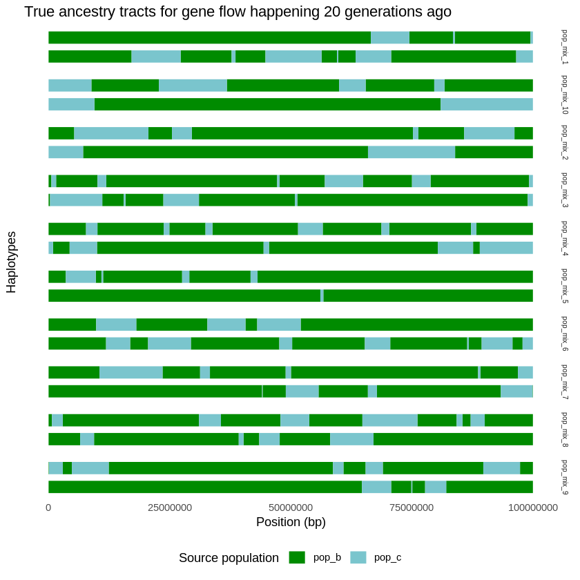

Each row is an individual from pop_mix with its two haplotypes. The colour of each segment indicates the ancestry from which it came from (either pop_b or pop_c).

##### Now looking at gene flow happening 200 generations ago:

```
library(ggplot2)
suppressMessages(library(dplyr))
options(scipen=999)

tracts_200 <- read.delim('~/data_folder/model_gen_adm_200_tracts.tsv')

values = c("pop_b" = "green4",
           "pop_c" = "cadetblue3")

tracts_200 %>%
  mutate(chrom = paste(name, " (node", node_id, ")")) %>%
  ggplot(aes(x = left, xend = right, y = chrom, yend = chrom, color = source_pop)) +
  geom_segment(linewidth = 5) +
  scale_colour_manual(values = values, name="Source population") +
  theme_minimal() +
  theme(axis.text.y = element_blank(),
        panel.grid = element_blank(),
        legend.position = 'bottom',
        strip.text.y = element_text(size = 6)) +
  labs(x = "Position (bp)", y = "Haplotypes") +
  ggtitle("True ancestry tracts for gene flow happening 200 generations ago") +
  facet_grid(name ~ ., scales = "free_y")
```

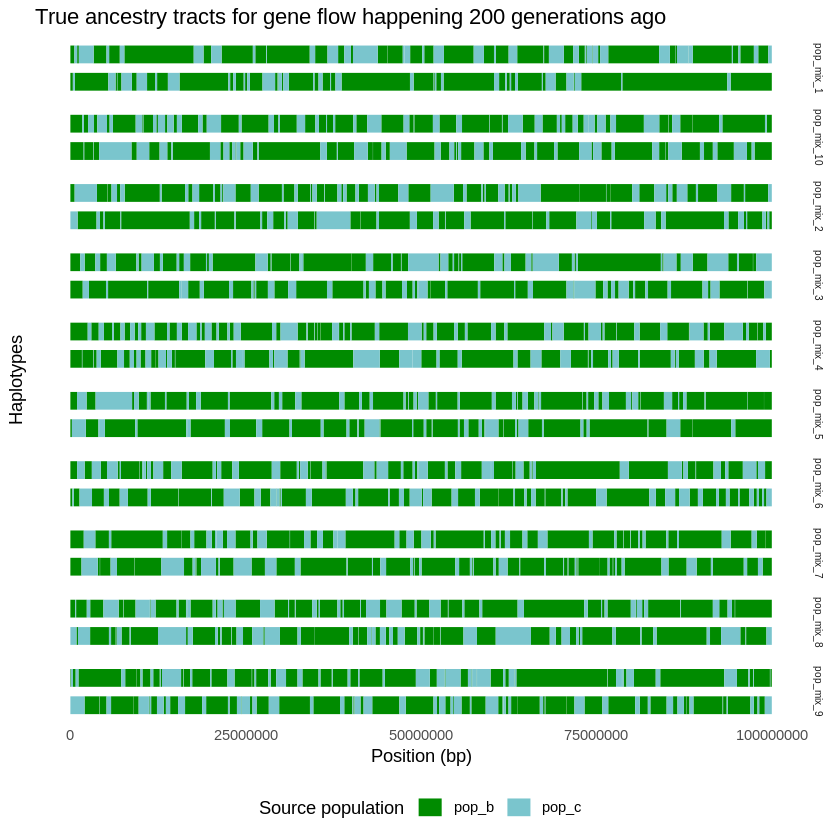

#### Q: What difference do we see in the tracts in each case? Why?

##### Let's look at the track length distribution:

```
tracts <- rbind(tracts_20, tracts_200)

tracts$adm_time_f = factor(tracts$adm_time, levels=c('20', '200'))

ggplot(tracts) +
  geom_histogram(
    aes(x = length, fill=source_pop),
    binwidth = 100000, alpha = 0.75
  ) +
  labs(
    x = "Tract length (bp)", y = "Density",
    title = "Tract length distribution"
  ) +
  scale_x_continuous(labels = scales::comma) +
  scale_fill_manual(values = values) +
  theme_bw() +
  theme(legend.position = "none",
        title =element_text(size=9),
        axis.text=element_text(size=9)) +
  facet_grid(adm_time_f~source_pop, scales = "free_y")
```

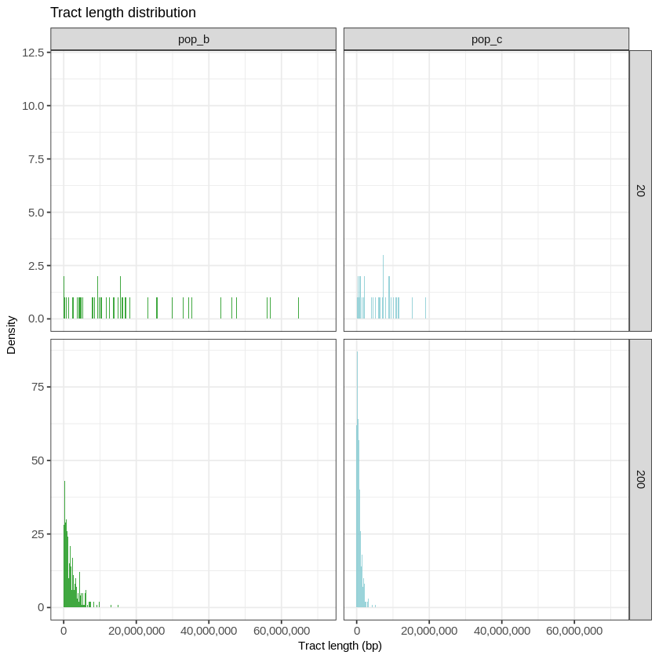

#### Q: Is this what we would expect? How come do we always have longer tracts of pop_b ancestry relative to pop_c tracts?

### Now let's test some LAI methods. For this exercise, we will use FLARE (Browning et al., 2023) and MOSAIC (Salter-Townshend & Myers, 2019).

The point of this exercise is to see how LAI method performance may vary depending on different aspects of our data, such as sample sizes and how far back the admixture time is.

You will find the files needed for each software in the following folders:

```
ls -1 ~/data_folder/FLARE/

echo ""

ls -1 ~/data_folder/MOSAIC/
```

```
gen_adm_200_source_20_source_time_0
gen_adm_20_source_20_source_time_0

gen_adm_200_source_20_source_time_0
gen_adm_20_source_20_source_time_0
```

#### Following the demographic scenarios pictured at the beginning of the exercise, we will infer local ancestry in target individuals from the pop_mix population, using samples from the pop_b and pop_c populations as sources. We will first focus on the case where gene flow happened 20 generations ago, using 20 samples from each of the two source populations (pop_b and pop_c) to "paint" the genomes of 10 individuals in the target population (pop_mix). Both source and target samples are sampled from the present (0 generations ago). We'll look at the results from the other scenarios later on.

### LAI using FLARE

##### FLARE is a recently developed LAI method, that has been tailored to run on large datasets with reduced computational time. Let's take a look at the input files needed:

```
ls -1 ~/data_folder/FLARE/gen_adm_20_source_20_source_time_0/
```

```
model_gen_adm_20-genetic_map.txt
model_gen_adm_20_filt.vcf.gz
output
source_name_pop_gen_adm_20_source_20_source_time_0.txt
target_name_gen_adm_20_source_20_source_time_0.txt
```

##### Let's look at each of the files in more detail:

```
adm20_flare=~/data_folder/FLARE/gen_adm_20_source_20_source_time_0/

#model_gen_adm_20_filt.vcf.gz: simulated VCF

#model_gen_adm_20-genetic_map.txt: genetic map with the following columns: chromosome, rs# or sno identifier, genetic distance (cM units), base-pair position
echo model_gen_adm_20-genetic_map.txt
head ${adm20_flare}/model_gen_adm_20-genetic_map.txt
echo ""

#source_name_pop_gen_adm_20_source_20_source_time_0.txt: file containing the source sample names (first column) and their population (second column)
echo source_name_pop_gen_adm_20_source_20_source_time_0.txt
head ${adm20_flare}/source_name_pop_gen_adm_20_source_20_source_time_0.txt
echo ""

#target_name_gen_adm_20_source_20_source_time_0.txt: file with target sample names (from pop_mix)
echo target_name_gen_adm_20_source_20_source_time_0.txt
head ${adm20_flare}/target_name_gen_adm_20_source_20_source_time_0.txt
```

```
model_gen_adm_20-genetic_map.txt
chr1 chr1_227 0.000227 227
chr1 chr1_709 0.000709 709
chr1 chr1_812 0.000812 812
chr1 chr1_1337 0.001337 1337
chr1 chr1_1380 0.00138 1380
chr1 chr1_1406 0.001406 1406
chr1 chr1_2594 0.002594 2594
chr1 chr1_3301 0.003301 3301
chr1 chr1_3644 0.003644 3644
chr1 chr1_4067 0.004067 4067

source_name_pop_gen_adm_20_source_20_source_time_0.txt
pop_b_51	pop_b
pop_b_52	pop_b
pop_b_53	pop_b
pop_b_54	pop_b
pop_b_55	pop_b
pop_b_56	pop_b
pop_b_57	pop_b
pop_b_58	pop_b
pop_b_59	pop_b
pop_b_60	pop_b

target_name_gen_adm_20_source_20_source_time_0.txt
pop_mix_1
pop_mix_2
pop_mix_3
pop_mix_4
pop_mix_5
pop_mix_6
pop_mix_7
pop_mix_8
pop_mix_9
pop_mix_10
```

##### Time to run FLARE (this might take a few minutes)

```
# Specify parameters

# Admixture time (generations before present)
GEN_ADM=20

# Number of samples from each source population
SOURCE=20

# Time point from which source samples were taken from (generations before present)
SOURCE_TIME=0

# Specify output path
FOLDER=~/data_folder/FLARE/gen_adm_${GEN_ADM}_source_${SOURCE}_source_time_${SOURCE_TIME}

# Specify input files
MAP=${FOLDER}/model_gen_adm_${GEN_ADM}-genetic_map.txt # Plink format genetic map
VCF=${FOLDER}/model_gen_adm_${GEN_ADM}_filt.vcf.gz # VCF with target and source samples
SOURCE_LIST=${FOLDER}/source_name_pop_gen_adm_${GEN_ADM}_source_${SOURCE}_source_time_${SOURCE_TIME}.txt # two column file with source sample names and source population name
TARGET_LIST=${FOLDER}/target_name_gen_adm_${GEN_ADM}_source_20_source_time_0.txt # file with target sample names (considered one population)

# Make output folder if not present
if [ ! -d ~/current_folder/flare_out ]; then
    mkdir -p ~/current_folder/flare_out
fi

# Prefix for output files
PREFIX=~/current_folder/flare_out/gen_adm_${GEN_ADM}_source_${SOURCE}_source_time_${SOURCE_TIME}-output

# Run FLARE
java -Xmx500g -jar ${FLARE} \
ref=${VCF} \
ref-panel=${SOURCE_LIST} \
gt=${VCF} \
map=${MAP} \
gt-samples=${TARGET_LIST} \
gen=${GEN_ADM} \
out=${PREFIX} \
min-mac=1 \
probs=true \
nthreads=4

# index anc.vcf.gz output file
bcftools index -f ~/current_folder/flare_out/gen_adm_${GEN_ADM}_source_${SOURCE}_source_time_${SOURCE_TIME}-output.anc.vcf.gz

# What each option represents:
# java -Xmx500g -jar programmes/flare.jar \
# ref: VCF file with source (reference) samples
# ref-panel: two column file with source sample names and source population name
# gt: VCF with target samples
# map: Plink format genetic map
# gt-samples: file with target sample names (considered one population)
# gen: number of generations since admixture (default is 10 if not specified)
# out: output file prefix
# min-mac: minimum minor allele count in the ref VCF
# probs: specified whether the posterior probabilities are reported
# nthreads: number of computational threads
```

```
Copyright (C) 2021-2023 Brian L. Browning
Enter "java -jar flare.jar" to print a list of command line arguments

Program             :  flare.jar  [ version 0.5.3, 24Jul25.e5b ]
Start Time          :  11:28 AM UTC on 06 Aug 2025
Max Memory          :  512000 MB

Parameters
  ref               :  /home/jupyter-shixu/data_folder/FLARE/gen_adm_20_source_20_source_time_0/model_gen_adm_20_filt.vcf.gz
  ref-panel         :  /home/jupyter-shixu/data_folder/FLARE/gen_adm_20_source_20_source_time_0/source_name_pop_gen_adm_20_source_20_source_time_0.txt
  gt                :  /home/jupyter-shixu/data_folder/FLARE/gen_adm_20_source_20_source_time_0/model_gen_adm_20_filt.vcf.gz
  map               :  /home/jupyter-shixu/data_folder/FLARE/gen_adm_20_source_20_source_time_0/model_gen_adm_20-genetic_map.txt
  out               :  /home/jupyter-shixu/current_folder/flare_out/gen_adm_20_source_20_source_time_0-output
  array             :  false
  min-maf           :  0.005
  min-mac           :  1
  probs             :  true
  gen               :  20.0
  em                :  true
  gt-samples        :  /home/jupyter-shixu/data_folder/FLARE/gen_adm_20_source_20_source_time_0/target_name_gen_adm_20_source_20_source_time_0.txt
  nthreads          :  4
  seed              :  -99999

Statistics
  reference samples :  40
  target samples    :  10
  markers           :  175780

Wallclock Time      :  25 seconds
End Time            :  11:29 AM UTC on 06 Aug 2025
```

##### Let's look at the output files:

```
GEN_ADM=20
SOURCE=20
SOURCE_TIME=0
PREFIX=~/current_folder/flare_out/gen_adm_${GEN_ADM}_source_${SOURCE}_source_time_${SOURCE_TIME}-output


# List files in output folder
ls ${PREFIX}*
```

```
/home/jupyter-shixu/current_folder/flare_out/gen_adm_20_source_20_source_time_0-output.anc.vcf.gz
/home/jupyter-shixu/current_folder/flare_out/gen_adm_20_source_20_source_time_0-output.anc.vcf.gz.csi
/home/jupyter-shixu/current_folder/flare_out/gen_adm_20_source_20_source_time_0-output.global.anc.gz
/home/jupyter-shixu/current_folder/flare_out/gen_adm_20_source_20_source_time_0-output.log
/home/jupyter-shixu/current_folder/flare_out/gen_adm_20_source_20_source_time_0-output.model
```

```
GEN_ADM=20
SOURCE=20
SOURCE_TIME=0
PREFIX=~/current_folder/flare_out/gen_adm_${GEN_ADM}_source_${SOURCE}_source_time_${SOURCE_TIME}-output

# Look at the global ancestry estimates
#zless -S ${PREFIX}.global.anc.gz
zcat ${PREFIX}.global.anc.gz
```

```
SAMPLE	pop_b	pop_c
pop_mix_1	0.743	0.257
pop_mix_2	0.677	0.323
pop_mix_3	0.768	0.232
pop_mix_4	0.759	0.241
pop_mix_5	0.909	0.091
pop_mix_6	0.687	0.313
pop_mix_7	0.789	0.211
pop_mix_8	0.745	0.255
pop_mix_9	0.788	0.212
pop_mix_10	0.688	0.312
```

```
GEN_ADM=20
SOURCE=20
SOURCE_TIME=0
PREFIX=~/current_folder/flare_out/gen_adm_${GEN_ADM}_source_${SOURCE}_source_time_${SOURCE_TIME}-output

# Look at the model output
cat ${PREFIX}.model
```

```
# list of ancestries
pop_b	pop_c

# list of reference panels
pop_b	pop_c

# T: number of generations since admixture
91.48827

# mu[i]: proportion of target genotypes with ancestry i
0.7924876	0.20751236


# p[i][j]: probability that a model state haplotype is in reference panel j
#          when the model state ancestry is i
0.88846797	0.11153202
0.11031648	0.88968354

# theta[i][j]: probability that a model state haplotype and the target
#              haplotype carry different alleles when the model state haplotype
#              is in reference panel j and the model state ancestry is i
0.0012769366	0.0012769366
0.0012769366	0.0012769366

# rho[i]: rate of the exponential IBD segment cM-length distribution when the
#         most recent common ancestor precedes admixture and has ancestry i
1370.1002	1335.1033
```

```
GEN_ADM=20
SOURCE=20
SOURCE_TIME=0
PREFIX=~/current_folder/flare_out/gen_adm_${GEN_ADM}_source_${SOURCE}_source_time_${SOURCE_TIME}-output

# Look at the log file which contains the summary of the analysis
cat ${PREFIX}.log
```

```
Copyright (C) 2021-2023 Brian L. Browning
Enter "java -jar flare.jar" to print a list of command line arguments

Program             :  flare.jar  [ version 0.5.3, 24Jul25.e5b ]
Start Time          :  11:28 AM UTC on 06 Aug 2025
Max Memory          :  512000 MB

Parameters
  ref               :  /home/jupyter-shixu/data_folder/FLARE/gen_adm_20_source_20_source_time_0/model_gen_adm_20_filt.vcf.gz
  ref-panel         :  /home/jupyter-shixu/data_folder/FLARE/gen_adm_20_source_20_source_time_0/source_name_pop_gen_adm_20_source_20_source_time_0.txt
  gt                :  /home/jupyter-shixu/data_folder/FLARE/gen_adm_20_source_20_source_time_0/model_gen_adm_20_filt.vcf.gz
  map               :  /home/jupyter-shixu/data_folder/FLARE/gen_adm_20_source_20_source_time_0/model_gen_adm_20-genetic_map.txt
  out               :  /home/jupyter-shixu/current_folder/flare_out/gen_adm_20_source_20_source_time_0-output
  array             :  false
  min-maf           :  0.005
  min-mac           :  1
  probs             :  true
  gen               :  20.0
  em                :  true
  gt-samples        :  /home/jupyter-shixu/data_folder/FLARE/gen_adm_20_source_20_source_time_0/target_name_gen_adm_20_source_20_source_time_0.txt
  nthreads          :  4
  seed              :  -99999

Statistics
  reference samples :  40
  target samples    :  10
  markers           :  175780

Wallclock Time      :  25 seconds
End Time            :  11:29 AM UTC on 06 Aug 2025
```

```
GEN_ADM=20
SOURCE=20
SOURCE_TIME=0
PREFIX=~/current_folder/flare_out/gen_adm_${GEN_ADM}_source_${SOURCE}_source_time_${SOURCE_TIME}-output

# Look at the file which contains the inferred local ancestry for each allele (we'll only view one sample to make it easier to the eye)
bcftools view -s pop_mix_1 ${PREFIX}.anc.vcf.gz | less -S | head -20
```

```
##fileformat=VCFv4.2
##FILTER=<ID=PASS,Description="All filters passed">
##filedate=20250806
##source=flare.24Jul25.e5b.jar
##FORMAT=<ID=GT,Number=1,Type=String,Description="Genotype">
##FORMAT=<ID=AN1,Number=1,Type=Integer,Description="Ancestry of first haplotype">
##FORMAT=<ID=AN2,Number=1,Type=Integer,Description="Ancestry of second haplotype">
##FORMAT=<ID=ANP1,Number=2,Type=Float,Description="Ancestry probabilities for first haplotype">
##FORMAT=<ID=ANP2,Number=2,Type=Float,Description="Ancestry probabilities for second haplotype">
##ANCESTRY=<pop_b=0,pop_c=1>
##contig=<ID=chr1>
##INFO=<ID=AC,Number=A,Type=Integer,Description="Allele count in genotypes">
##INFO=<ID=AN,Number=1,Type=Integer,Description="Total number of alleles in called genotypes">
##bcftools_viewVersion=1.13+htslib-1.13+ds
##bcftools_viewCommand=view -s pop_mix_1 /home/jupyter-shixu/current_folder/flare_out/gen_adm_20_source_20_source_time_0-output.anc.vcf.gz; Date=Wed Aug  6 11:29:33 2025
#CHROM	POS	ID	REF	ALT	QUAL	FILTER	INFO	FORMAT	pop_mix_1
chr1	227	0	T	G	.	.	AC=1;AN=2	GT:AN1:AN2:ANP1:ANP2	0|1:0:0:1,0:1,0
chr1	709	2	T	G	.	.	AC=0;AN=2	GT:AN1:AN2:ANP1:ANP2	0|0:0:0:1,0:1,0
chr1	812	3	A	T	.	.	AC=0;AN=2	GT:AN1:AN2:ANP1:ANP2	0|0:0:0:1,0:1,0
chr1	1337	4	G	T	.	.	AC=0;AN=2	GT:AN1:AN2:ANP1:ANP2	0|0:0:0:1,0:1,0
```

Take some time to understand the FORMAT field entries AN1, AN2, ANP1, ANP2.

#### Q: What ancestry or ancestries is the first position of sample pop_mix_1 assigned to? Why?

### LAI using MOSAIC

##### MOSAIC is an LAI method which allows for unknown relationships between reference panels (sources) of ancestry. Let's take a look at the input files needed:

```
ls -1 ~/data_folder/MOSAIC/gen_adm_20_source_20_source_time_0/
```

```
coancestry_curves.png
model_gen_adm_20_filt.vcf.gz
model_gen_adm_20_filt.vcf.gz.csi
output
pop_bgenofile.1
pop_cgenofile.1
pop_mixgenofile.1
rates.1
sample.names
snpfile.1
```

```
adm20_mosaic=~/data_folder/MOSAIC/gen_adm_20_source_20_source_time_0/

#model_gen_adm_20_filt.vcf.gz: simulated VCF file

#pop_bgenofile.1: genotype file of pop_b samples
echo pop_bgenofile.1
head ${adm20_mosaic}/pop_bgenofile.1
echo ""

#pop_cgenofile.1: genotype file of pop_c samples
echo pop_cgenofile.1
head ${adm20_mosaic}/pop_cgenofile.1
echo ""

#pop_mixgenofile.1: genotype file of pop_mix samples
echo pop_mixgenofile.1
head ${adm20_mosaic}/pop_mixgenofile.1
echo ""

#sample.names: file with population in first column and sample names in second column
echo sample.names
cat ${adm20_mosaic}/sample.names
echo""

#snpfile.1: file with one snp per row and 6 columns: rsID, chr, distance, position, allele ?, allele ?.
echo snpfile.1
head ${adm20_mosaic}/snpfile.1
echo""
```

```
pop_bgenofile.1
0000000010000000010000000001101000000000
0110000000000001000000011000000000001100
0000000000000000000000000000001000000000
0000010001000000001110000100000111000001
0000000010000000010000000001100000000000
0000000000000000000000000000000000000000
0000010001000000001110000100000111000001
0000010001000000101111100100000111000001
0000000000000000000000000000000000000000
0000000000000000000000000000000000000000

pop_cgenofile.1
0000000000000000001000000000100000000110
0000110100011010000000000000000100001000
0000000000000000001000000000100000000110
0010000001000100010000101100010010000000
0000000000000000000000000000000000000000
0000110000000010000000000000000100001000
1011000001000100010000101110010010000000
1011000001000100010000101110010011000000
0000000000100000000000000000000000000000
0000000000000000000000000000000000000000

pop_mixgenofile.1
01000000000001010000
00010000000000000100
00000000000000000000
00101010011000101001
01000000000001010000
00000000000000000000
00101010011000101001
10101010011110101011
00000000000000000000
00000000000000000000

sample.names
pop_b	pop_b_51
pop_b	pop_b_52
pop_b	pop_b_53
```

[output cut: 44 more lines]

```
pop_mix	pop_mix_8
pop_mix	pop_mix_9
pop_mix	pop_mix_10

snpfile.1
1_227 1 0 227 T G
1_709 1 0 709 T G
1_812 1 0 812 A T
1_1337 1 0 1337 G T
1_1380 1 0 1380 G A
1_1406 1 0 1406 G C
1_2594 1 0 2594 C G
1_3301 1 0 3301 C A
1_3644 1 0 3644 C G
1_4067 1 0 4067 G A
```

```
adm20_mosaic=~/data_folder/MOSAIC/gen_adm_20_source_20_source_time_0/

#rates.1: Recombination rates file for MOSAIC, has a bit of a weird format compared to normal genetic maps
echo rates.1

#3 rows with #sites, position, cumulative recombination rate (in centiMorgans).

# the first row shows the number of sites
sed -n '1p' ${adm20_mosaic}/rates.1

# the second row shows the snp positions
sed -n '2p' ${adm20_mosaic}/rates.1 | cut -d " " -f 1-10

# the second row shows the snp positions
sed -n '3p' ${adm20_mosaic}/rates.1 | cut -d " " -f 1-10
```

```
rates.1
:sites:193376
227 709 812 1337 1380 1406 2594 3301 3644 4067
0.000227 0.000709 0.000812 0.001337 0.00138 0.001406 0.002594 0.003301 0.003644 0.004067
```

##### Run MOSAIC. This will take a couple of minutes, so time to take a break!

[output not shown]

```
using 16 cores
mapping chr 1 to a grid...
Finding number at each location on chr 1 ...

Fitting model to 10 pop_mix 2-way admixed target individuals using 2 panels
EM inference is  on  and re-phasing is  off
Initialise parameters of MOSAIC based on ancestry unaware copying probabilities

Fitting no-ancestry model
2 %:  -283856.2 ( NaN )
4 %:  -283671 ( 185.1903 )
6 %:  -283645.2 ( 25.80271 )
8 %:  -283641.5 ( 3.744086 )
10 %:  -283640.9 ( 0.5460978 )
12 %:  -283640.9 ( 0.07975182 )
14 %:  -283640.8 ( 0.01164796 )
16 %:  -283640.8 ( 0.00169987 )
EM iterations have converged

######################## round  1 of  5 #######################
10 %:  -283026.6 ( NaN )
20 %:  -282644.9 ( 381.6679 )
30 %:  -282535.5 ( 109.4643 )
40 %:  -282486.7 ( 48.75729 )
50 %:  -282456.2 ( 30.54348 )
60 %:  -282432.9 ( 23.24346 )
70 %:  -282413.7 ( 19.24931 )
80 %:  -282397.4 ( 16.30889 )
90 %:  -282383.5 ( 13.8621 )
100 %:  -282371.7 ( 11.80798 )
######################## round  2 of  5 #######################
10 %:  -282361.6 ( 10.04165 )
20 %:  -282353.2 ( 8.475778 )
30 %:  -282346.1 ( 7.065682 )
40 %:  -282340.3 ( 5.800198 )
50 %:  -282335.6 ( 4.68339 )
60 %:  -282331.9 ( 3.719971 )
70 %:  -282329 ( 2.90814 )
80 %:  -282326.8 ( 2.238707 )
90 %:  -282325.1 ( 1.69761 )
```

[output cut: 28 more lines]

```
saving localanc results to file
calculating ancestry aware re-phased coancestry curves
calculating Fst values
Saving frequencies of simulated data
Saving SNP frequencies of pop_b
Saving SNP frequencies of pop_c
saving final results to file
Expected r-squared (genomewide): 0.8747759
Fst between mixing groups:
 anc1xanc2
0.07383972
Rst between mixing groups:
anc1xanc2
0.1103045
saving plots to  MOSAIC_RESULTS folder
```

##### Let's now plot the inferred tracts from the two methods and compare them with the true tracts we extracted from the simulated data. We've formatted the output of each method so that we have all the tracts in the same format. You can find them here, with seperate files for haplotypes 1 and 2

```
ls ~/data_folder/all_tracts/model_gen_adm_20_source_20_source_time_0_prob_0.0_all_tracts_hap*.tsv
```

```
/home/jupyter-shixu/data_folder/all_tracts/model_gen_adm_20_source_20_source_time_0_prob_0.0_all_tracts_hap1.tsv
/home/jupyter-shixu/data_folder/all_tracts/model_gen_adm_20_source_20_source_time_0_prob_0.0_all_tracts_hap2.tsv
```

##### Look at the format of the hap1 file:

```
head -n 50 ~/data_folder/all_tracts/model_gen_adm_20_source_20_source_time_0_prob_0.0_all_tracts_hap1.tsv
```

```
name	source_pop	left	right	type
pop_mix_1	pop_b	0	17138143	true
pop_mix_10	pop_b	0	0	true
pop_mix_2	pop_b	0	0	true
pop_mix_3	pop_b	0	304274	true
pop_mix_4	pop_b	0	0	true
pop_mix_5	pop_b	0	56114516	true
pop_mix_6	pop_b	0	11865692	true
pop_mix_7	pop_b	0	44081083	true
pop_mix_8	pop_b	0	6511979	true
pop_mix_9	pop_b	0	64699908	true
pop_mix_1	pop_b	27266540	37790530	true
pop_mix_1	pop_b	38592738	44781624	true
pop_mix_1	pop_b	56366814	59537961	true
pop_mix_1	pop_b	59814192	63393372	true
pop_mix_1	pop_b	70729157	96546961	true
pop_mix_1	pop_b	100000001	100000000	true
pop_mix_2	pop_b	7131159	65949885	true
pop_mix_2	pop_b	83936363	100000000	true
pop_mix_3	pop_b	11089689	15513753	true
pop_mix_3	pop_b	15884175	23703219	true
pop_mix_3	pop_b	31048296	50866980	true
pop_mix_3	pop_b	51351716	98927992	true
pop_mix_3	pop_b	100000001	100000000	true
pop_mix_4	pop_b	919828	4343004	true
pop_mix_4	pop_b	10001434	44393991	true
pop_mix_4	pop_b	45512090	80361251	true
pop_mix_4	pop_b	87649495	89034343	true
pop_mix_4	pop_b	100000001	100000000	true
pop_mix_5	pop_b	56735853	100000000	true
pop_mix_6	pop_b	16841785	20542817	true
pop_mix_6	pop_b	29380669	47635518	true
pop_mix_6	pop_b	50291271	65295682	true
pop_mix_6	pop_b	70545662	86440114	true
pop_mix_6	pop_b	86774609	89418066	true
pop_mix_6	pop_b	95782166	97865295	true
pop_mix_6	pop_b	100000001	100000000	true
pop_mix_7	pop_b	44187612	48979880	true
pop_mix_7	pop_b	55743429	65929637	true
pop_mix_7	pop_b	67801377	93378859	true
pop_mix_7	pop_b	99925808	100000000	true
pop_mix_8	pop_b	9387786	39261840	true
pop_mix_8	pop_b	40253526	43491483	true
pop_mix_8	pop_b	47715742	58135690	true
pop_mix_8	pop_b	67089979	100000000	true
pop_mix_9	pop_b	70731882	74902687	true
pop_mix_9	pop_b	75101950	77740781	true
pop_mix_9	pop_b	82099817	100000000	true
pop_mix_10	pop_b	9463384	80959208	true
pop_mix_10	pop_b	100000001	100000000	true
```

##### Plot true and inferred tracts:

```
# import libraries
library(ggplot2)
suppressMessages(library(dplyr))

tracks_hap1 <- read.delim('~/data_folder/all_tracts/model_gen_adm_20_source_20_source_time_0_prob_0.0_all_tracts_hap1.tsv')
tracks_hap2 <- read.delim('~/data_folder/all_tracts/model_gen_adm_20_source_20_source_time_0_prob_0.0_all_tracts_hap2.tsv')

values = c("pop_b" = "chartreuse4",
           "pop_c" = "cyan3")

# Let's plot three samples from the pop_mix population
samples <- c('pop_mix_1', 'pop_mix_2', 'pop_mix_3')

ggplot()+
  geom_segment(data=tracks_hap1 %>% filter(name %in% samples), aes(y = type, yend = type, x = left/1000000, xend = right/1000000, colour=source_pop), linewidth = 12) +
  geom_segment(data=tracks_hap2 %>% filter(name %in% samples), aes(y = type, yend = type, x = left_2/1000000, xend = right_2/1000000, colour=source_pop), linewidth = 12) +
  theme_bw()+
  theme(panel.spacing.y=unit(0.1, "lines"),
        axis.title.x = element_text(margin=margin(t=5)),
        axis.title.y = element_text(margin=margin(r=5)),
        axis.text.x = element_text(color = "black"),
        axis.ticks.x = element_line(linewidth = 0.3),
        plot.margin = margin(r = 0.5, l = 0.1, b = 0.5, unit = "cm"),
        axis.line.y = element_blank(),
        axis.ticks.y = element_blank(),
        strip.text.y.left = element_text(size = 10, angle = 0),
        legend.position = 'none',
        strip.background =element_rect(fill="gray28"),
        strip.text = element_text(colour = 'white')
  ) +
  scale_color_manual(name = "Ancestry", values = values) +
  ylab("Sample") +
  xlab("Genome position (Mb)") +
  ggtitle("True and inferred ancestry tracts - gen_adm=20 generations ago") +
  facet_grid(name~.)
```

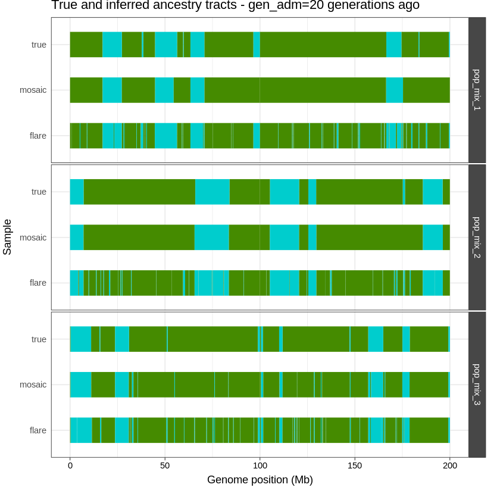

Each panel is a sample from the pop_mix population (only 3 samples shown in this plot) with its true and inferred ancestry tracts from MOSAIC and FLARE. Note that the two haplotypes have been "merged" as a continuous long chromosome. The colour of each segment indicates the ancestry from which it came from (either pop_b as green or pop_c as blue).

#### Q: How do the inferred ancesrty tracts look compared to the true ones?

##### Now let's see how the inferred tracts look like if we focus on a scenario where gene flow from pop_c into pop_mix happened 200 generations ago instead. We've already run the local ancestry inference methods and have the tracts ready to plot:

```
# import libraries
library(ggplot2)
suppressMessages(library(dplyr))

tracks_hap1 <- read.delim('~/data_folder/all_tracts/model_gen_adm_200_source_20_source_time_0_prob_0.0_all_tracts_hap1.tsv')
tracks_hap2 <- read.delim('~/data_folder/all_tracts/model_gen_adm_200_source_20_source_time_0_prob_0.0_all_tracts_hap2.tsv')

values = c("pop_b" = "chartreuse4",
           "pop_c" = "cyan3")

# Let's plot three samples from the pop_mix population
samples <- c('pop_mix_1', 'pop_mix_2', 'pop_mix_3')

ggplot()+
  geom_segment(data=tracks_hap1 %>% filter(name %in% samples), aes(y = type, yend = type, x = left/1000000, xend = right/1000000, colour=source_pop), linewidth = 12) +
  geom_segment(data=tracks_hap2 %>% filter(name %in% samples), aes(y = type, yend = type, x = left_2/1000000, xend = right_2/1000000, colour=source_pop), linewidth = 12) +
  theme_bw()+
  theme(panel.spacing.y=unit(0.1, "lines"),
        axis.title.x = element_text(margin=margin(t=5)),
        axis.title.y = element_text(margin=margin(r=5)),
        axis.text.x = element_text(color = "black"),
        axis.ticks.x = element_line(linewidth = 0.3),
        plot.margin = margin(r = 0.5, l = 0.1, b = 0.5, unit = "cm"),
        axis.line.y = element_blank(),
        axis.ticks.y = element_blank(),
        strip.text.y.left = element_text(size = 10, angle = 0),
        legend.position = 'none',
        strip.background =element_rect(fill="gray28"),
        strip.text = element_text(colour = 'white')
  ) +
  scale_color_manual(name = "Ancestry", values = values) +
  ylab("Sample") +
  xlab("Genome position (Mb)") +
  ggtitle("True and inferred ancestry tracts - gen_adm=200 generations ago") +
  facet_grid(name~.)
```

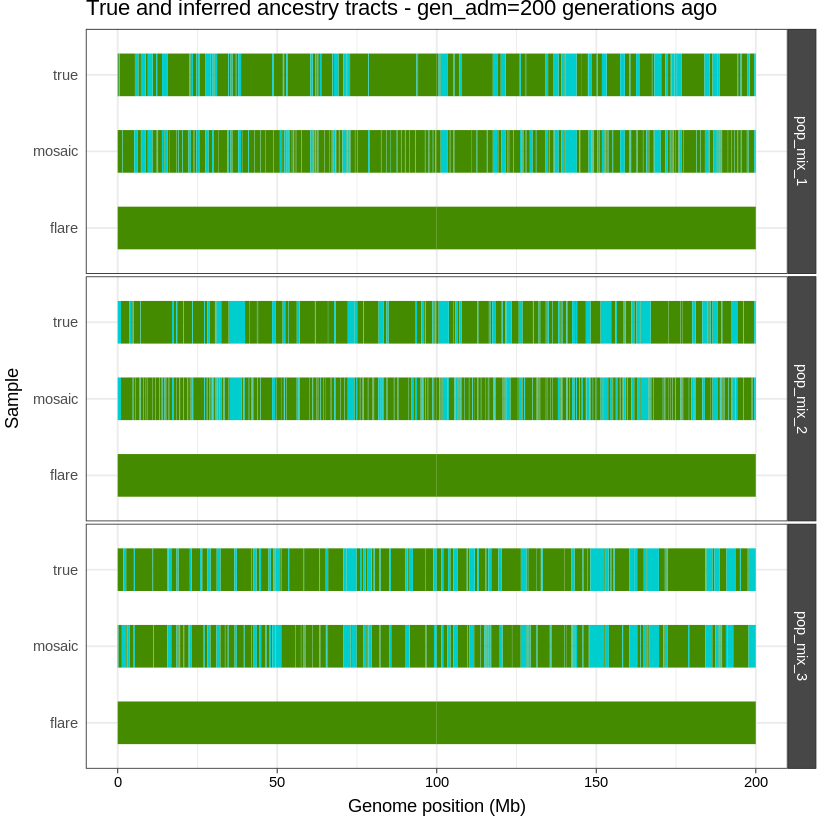

#### Q: Does the overlap seem to change? Why?

##### Let's now see what happens to the above scenario if we increase the sample size of sources from pop_b and pop_c from 20 to 50. Again, we have re-run the analyses in FLARE and MOSAIC and have the tracts ready to view:

```
# import libraries
library(ggplot2)
suppressMessages(library(dplyr))

tracks_hap1 <- read.delim('~/data_folder/all_tracts/model_gen_adm_200_source_50_source_time_0_prob_0.0_all_tracts_hap1.tsv')
tracks_hap2 <- read.delim('~/data_folder/all_tracts/model_gen_adm_200_source_50_source_time_0_prob_0.0_all_tracts_hap2.tsv')

values = c("pop_b" = "chartreuse4",
           "pop_c" = "cyan3")

# Let's plot three samples from the pop_mix population
samples <- c('pop_mix_1', 'pop_mix_2', 'pop_mix_3')

ggplot()+
  geom_segment(data=tracks_hap1 %>% filter(name %in% samples), aes(y = type, yend = type, x = left/1000000, xend = right/1000000, colour=source_pop), linewidth = 12) +
  geom_segment(data=tracks_hap2 %>% filter(name %in% samples), aes(y = type, yend = type, x = left_2/1000000, xend = right_2/1000000, colour=source_pop), linewidth = 12) +
  theme_bw()+
  theme(panel.spacing.y=unit(0.1, "lines"),
        axis.title.x = element_text(margin=margin(t=5)),
        axis.title.y = element_text(margin=margin(r=5)),
        axis.text.x = element_text(color = "black"),
        axis.ticks.x = element_line(linewidth = 0.3),
        plot.margin = margin(r = 0.5, l = 0.1, b = 0.5, unit = "cm"),
        axis.line.y = element_blank(),
        axis.ticks.y = element_blank(),
        strip.text.y.left = element_text(size = 10, angle = 0),
        legend.position = 'none',
        strip.background =element_rect(fill="gray28"),
        strip.text = element_text(colour = 'white')
  ) +
  scale_color_manual(name = "Ancestry", values = values) +
  ylab("Sample") +
  xlab("Genome position (Mb)") +
  ggtitle("True and inferred ancestry tracts - gen_adm=200 generations ago") +
  facet_grid(name~.)
```

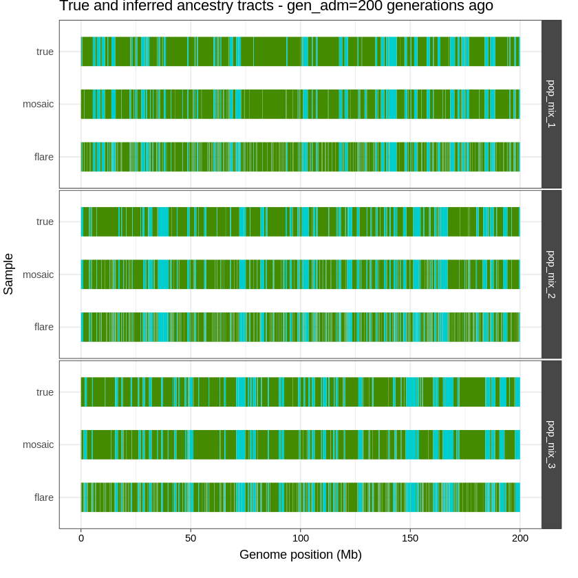

Seems a lot better!

#### Q: Why does increasing sample size improve the local ancestry inference?

##### One final thing we will check is how the differentiation between sources can impact the local ancestry inference.

##### Focusing again on gene flow happening 20 generations ago, let's look at the metadata file with our sample info from the simulation:

```
suppressMessages(library(dplyr))

meta <- read.delim('~/data_folder/model_gen_adm_20_meta.tsv')
meta %>%
    group_by(time, pop) %>%
    tally()
```

A grouped_df: 5 × 3

| time <int> | pop <chr> | n <int> |
| --- | --- | --- |
| 0 | pop_b | 50 |
| 0 | pop_c | 50 |
| 0 | pop_mix | 10 |
| 1200 | pop_b | 50 |
| 1200 | pop_c | 50 |

We can see that we have 10 individuals from pop_mix from one time point (0, present), and 50 from pop_b and 50 from pop_c from two different time points (0 and 1200). Let's see what happens if instead of using source samples from the present (0 generations before present), we take them from 1200 generations before present, and re-run the local ancestry inference methods:

```
# import libraries
library(ggplot2)
suppressMessages(library(dplyr))

tracks_hap1 <- read.delim('~/data_folder/all_tracts/model_gen_adm_20_source_20_source_time_1200_prob_0.0_all_tracts_hap1.tsv')
tracks_hap2 <- read.delim('~/data_folder/all_tracts/model_gen_adm_20_source_20_source_time_1200_prob_0.0_all_tracts_hap2.tsv')

values = c("pop_b" = "chartreuse4",
           "pop_c" = "cyan3")

# Let's plot three samples from the pop_mix population
samples <- c('pop_mix_1', 'pop_mix_2', 'pop_mix_3')

ggplot()+
  geom_segment(data=tracks_hap1 %>% filter(name %in% samples), aes(y = type, yend = type, x = left/1000000, xend = right/1000000, colour=source_pop), linewidth = 12) +
  geom_segment(data=tracks_hap2 %>% filter(name %in% samples), aes(y = type, yend = type, x = left_2/1000000, xend = right_2/1000000, colour=source_pop), linewidth = 12) +
  theme_bw()+
  theme(panel.spacing.y=unit(0.1, "lines"),
        axis.title.x = element_text(margin=margin(t=5)),
        axis.title.y = element_text(margin=margin(r=5)),
        axis.text.x = element_text(color = "black"),
        axis.ticks.x = element_line(linewidth = 0.3),
        plot.margin = margin(r = 0.5, l = 0.1, b = 0.5, unit = "cm"),
        axis.line.y = element_blank(),
        axis.ticks.y = element_blank(),
        strip.text.y.left = element_text(size = 10, angle = 0),
        legend.position = 'none',
        strip.background =element_rect(fill="gray28"),
        strip.text = element_text(colour = 'white')
  ) +
  scale_color_manual(name = "Ancestry", values = values) +
  ylab("Sample") +
  xlab("Genome position (Mb)") +
  ggtitle("True and inferred ancestry tracts - gen_adm=20 generations ago") +
  facet_grid(name~.)
```

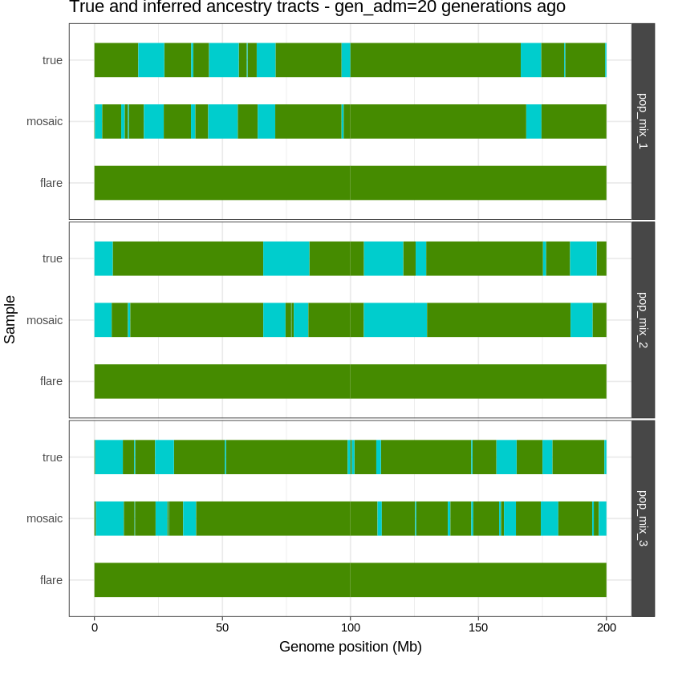

Hmm, seems like FLARE is having difficulty inferring the tracts (remember a few plots above it did quite well when using sources from the present (0 generations ago)?

#### Q: Do you have any feeling why this might be the case? (Hint: Take a look at the FST calculations we did at the beginning of the exercise)

So we can see that LAI methods can be sensitive to how old the admixture event was, the sample sizes used and the level of differentiation between the sources used.

### BONUS: Infering admixture times

Some LAI methods also infer the timing of admixture, or more specifically, how many generations prior to the age of the target individual(s) did the admixture event happen.

##### Let's go back to the output from MOSAIC and check how the inferred times perform for the admixture event happening 20 generations ago:

```
import os
from IPython.display import Image
Image(filename=os.path.expanduser('~/data_folder/MOSAIC/gen_adm_20_source_20_source_time_0/coancestry_curves.png'))
```

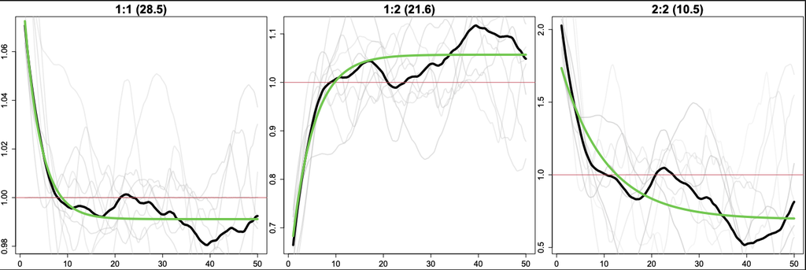

The above plots are coancestry curves as produced by MOSAIC. They capture information about the lengths of segments inherited from each source population (here shown as numbers 1 and 2). They show how rapidly the ancestry changes as genetic distance increases across the chromosome.

So if we take two locations of the genome seperated by a specific distance, we can see if the ancestry changes or not. If we do that over different genetic distances across the genome, we can construct these curves that show the length of segments from the source groups.

These curves should theoretically follow an exponential distribution with rate equal to the number of generations since the admixture event happened.

Each of these curves is governed by an admixture parameter lambda (λ), which drives the exponential decay of tract lengths since admixture. For our given two-way admixture model, we will average across the 3 estimates of the λ parameter outputted by MOSAIC, in order to report an admixture time.

The y axis shows the ratio of probabilities of pairs of local ancestries. The x axis is the genetic distance in cM. Looking at the first plot, we can see that the probability of going from ancestry 1 to ancestry 1 at two different genetic sites across the chromosome decreases with increasing genetic distance. Same thing in the 3rd plot going from ancestry 2 to ancestry 2. In the second plot, we see that you're more likely to switch ancestries the further you go down the chromosome.

The green line is the fitted curve, the black line is the observed ratios across targets and the grey line is the per target ratio.

If we calculate the average across the three coancestry curves we get 20.2 generations before present, which is almost spot on with the actual admixture event!

More info here: https://www.chg.ox.ac.uk/~gav/admixture/2014-science-final/resources/FAQ.pdf ("under What are coancestry curves?")

##### Now let's look a the coancestry curves for the admixture event happening 200 generations ago:

```
import os
from IPython.display import Image
Image(filename=os.path.expanduser('~/data_folder/MOSAIC/gen_adm_200_source_20_source_time_0/coancestry_curves.png'))
```

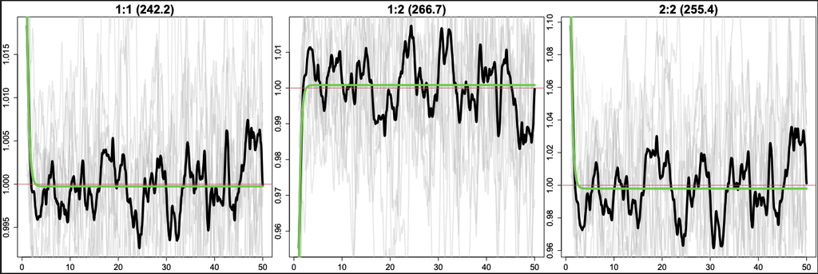

We can see that this is much more noisy and a bit more tricky to infer, considering that the admixture event is older in time, and therefore a lot of the ancestry tracts across the genome have been broken down into smaller segments due to recombination.

The average inferred admixture time across the three curves is 254.7 generations ago. This is not too far off from the truth, but we should always be cautious when interpreting results, especially for old admixture events.